# Guía complementaria · Integración TD + FD + PD (Taller 4)

- Mostrar todo el código
- Ocultar todo el código
- Ver el código fuente

Diversidad multidimensional · Semana 13 · 2026-II

Guía de consulta con los temas del Taller 4 que no caben en la sesión, con el mismo caso guiado de peces de México y pensada para el estudio de caso.

Autor/a

[Javier Rodríguez-Barrios](https://www.unimagdalena.edu.co/)

Fecha de publicación

25 de octubre de 2026

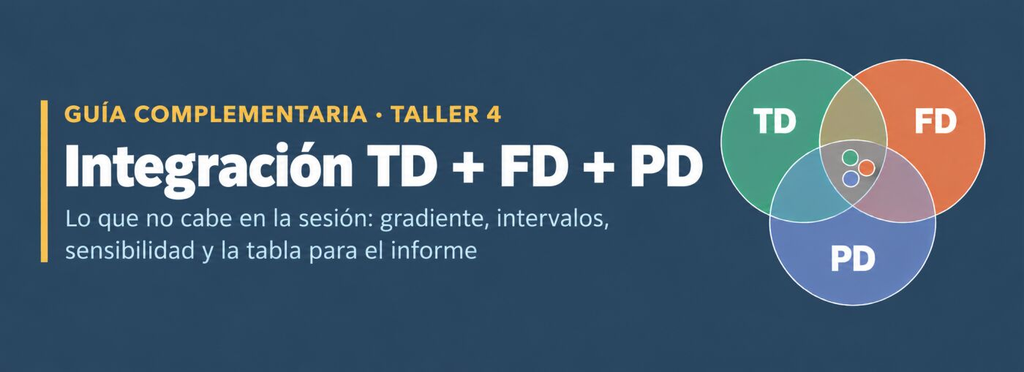

**NotaCómo usar esta guía**

Esta guía reúne los temas del Taller 4 que **no caben en la sesión de clase** pero que ayudan a defender la integración TD + FD + PD en el estudio de caso. Cada sección es independiente y responde una pregunta concreta.

| Sección | Pregunta que responde | Sección del taller |
| --- | --- | --- |
| 1 | ¿Las tres dimensiones responden igual a lo largo del río? | Escala de sitio |
| 2 | ¿Las brechas entre dimensiones son reales o efecto del azar? | 4 y 5 |
| 3 | ¿Cuánto depende la integración de la calidad de los rasgos? | 3 y 4 |
| 4 | ¿Cómo se reportan las diferencias en una escala de 0 a 1? | 4.2 |
| 5 | ¿Cómo se presenta la integración en el documento del estudio de caso? | 7 |
| 6 | Escenarios y redacciones para practicar | Todas |

Para ejecutarla se necesitan en la misma carpeta los archivos del taller (`datos.xlsx`, `arbol_filo_beta.rds`, `Rao.R`, `alineador.R`, `preparar_taller3.R`) y `integrar_3d.R`, que trae la misma función de la sección 4 del taller.

**Código**

```r
source("preparar_taller3.R")   # Crea biol1, zonas, rasgos1, rasgos.d, arbol_filo, phylo.d, biol_zona, zonas_id, cols_zona...
source("Rao.R")                # Rao(): partición de Rao (TD, FD, PD)
source("alineador.R")          # alinear_beta(): pares alineados con el árbol
source("integrar_3d.R")        # integrar_3d(): Hill alfa y beta a cobertura común (sección 4 del taller)

suppressPackageStartupMessages({
  library(kableExtra);
  library(iNEXT.3D);
  library(iNEXT.beta3D)
})

# Formato común de tablas (coma decimal)
tabla <- function(x, caption, digits = 3) {
  x %>%
    kbl(booktabs = TRUE,
        digits = digits,
        align = "c",
        caption = caption,
        format.args = list(decimal.mark = ",",
                           big.mark = ".")) %>%
    kable_styling(bootstrap_options = c("striped", "hover", "condensed"),
                  full_width = FALSE, position = "center") %>%
    row_spec(0, bold = TRUE,
             color = "white",
             background = "#2E4057")
}
dec  <- function(x, d = 2) format(round(x, d),
                                  nsmall = d,
                                  decimal.mark = ",")   # Números en el texto
coma <- scales::label_number(decimal.mark = ",",
                             big.mark = ".")                 # Ejes de las figuras
cols_dim <- c(TD = "#2E8F5A",
              FD = "#C6801E",
              PD = "#172C4B")                    # Colores del taller
cols_par <- c(M_vs_P = "#9AA5B1",
              M_vs_RM = "#172C4B",
              P_vs_RM = "#E0A04A")
```

**Código**

```r
int3d <- integrar_3d(biol_zona, rasgos.d, arbol_filo)   # El mismo resultado de la sección 4 del taller
```

# 1. ¿Las tres dimensiones responden igual a lo largo del río?

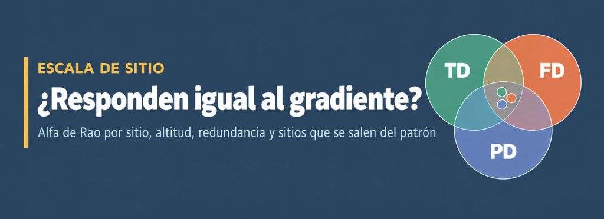

En el taller se compararon tres zonas. Con 42 sitios se puede preguntar algo distinto: **¿las tres dimensiones varían juntas a lo largo del río?** Se usa la alfa de Rao por sitio en números equivalentes y la altitud de la hoja `amb` como eje del gradiente.

## 1.1 Alfa por sitio y correlaciones

**Código**

```r
rao_sitios <- Rao(t(biol1),                # Especies (filas) x sitios (columnas): escala de sitio
                  dfunc = rasgos.d,
                  dphyl = phylo.d,
                  weight = FALSE,
                  Jost = TRUE)             # Números equivalentes: comparables entre dimensiones

amb <- read_xlsx("datos.xlsx", sheet = "amb") %>%
  transmute(Sites = str_remove_all(Sites,
                                   "[^A-Za-z0-9]"),   # Quita caracteres ocultos (Taller 1)
            Altitud = Altitude1)                      # Altitud del sitio (m s. n. m.)

sitios_3d <- tibble(
  Sites = rownames(biol1),
  S  = rowSums(biol1 > 0),                 # Riqueza observada
  TD = as.numeric(rao_sitios$TD$Alpha),    # Simpson inverso (especies efectivas)
  FD = as.numeric(rao_sitios$FD$Alpha),    # Rao funcional en números equivalentes
  PD = as.numeric(rao_sitios$PD$Alpha)     # Rao filogenético en números equivalentes
) %>%
  left_join(zonas, by = "Sites") %>%       # Zona de cada sitio
  left_join(amb, by = "Sites")             # Altitud de cada sitio

stopifnot(!anyNA(sitios_3d$Altitud))       # Todos los sitios deben tener altitud

cor(sitios_3d[, c("S", "TD", "FD",
                  "PD", "Altitud")],
    method = "spearman") %>%               # Rangos: robusto a valores extremos
  round(2) %>%
  tabla("Correlación de Spearman entre dimensiones y con la altitud (42 sitios)", digits = 2)
```

Correlación de Spearman entre dimensiones y con la altitud (42 sitios)

|  | S | TD | FD | PD | Altitud |
| --- | --- | --- | --- | --- | --- |
| S | 1,00 | 0,65 | 0,42 | 0,44 | -0,52 |
| TD | 0,65 | 1,00 | 0,78 | 0,78 | -0,69 |
| FD | 0,42 | 0,78 | 1,00 | 0,80 | -0,66 |
| PD | 0,44 | 0,78 | 0,80 | 1,00 | -0,45 |
| Altitud | -0,52 | -0,69 | -0,66 | -0,45 | 1,00 |

**Código**

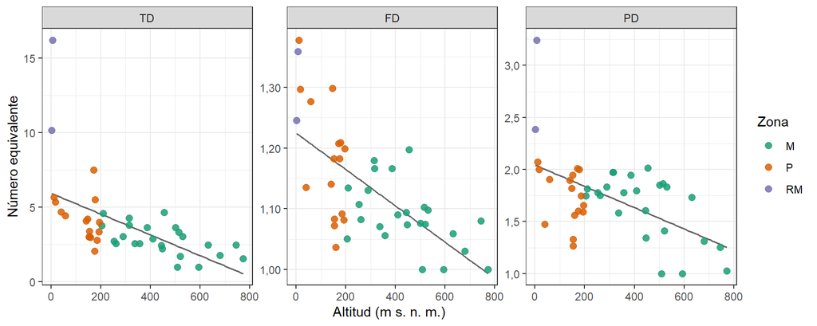

Figura 1: Diversidad alfa de Rao por sitio (números equivalentes) en cada dimensión frente a la altitud. La línea es una tendencia lineal de referencia.

```r
sitios_3d %>%
  pivot_longer(c(TD, FD, PD),
               names_to = "Dimension",
               values_to = "Valor") %>%   # Formato largo para facetas
  mutate(Dimension = factor(Dimension,
                            levels = c("TD", "FD", "PD"))) %>%
  ggplot(aes(Altitud, Valor)) +
  geom_smooth(method = "lm",
              formula = y ~ x,
              se = FALSE,
              color = "grey40",
              linewidth = 0.7) +
  geom_point(aes(color = Zona),
             size = 2.3,
             alpha = 0.85) +
  facet_wrap(~ Dimension,
             scales = "free_y") +
  scale_color_manual(values = cols_zona) +
  scale_y_continuous(labels = coma) +
  labs(x = "Altitud (m s. n. m.)",
       y = "Número equivalente") +
  theme_bw(base_size = 11)
```

**NotaLectura del gradiente**

- Las tres dimensiones **disminuyen río arriba** y están correlacionadas entre sí (ρ entre 0,78 y 0,80): a escala de sitio, la respuesta principal es **congruente** (Devictor et al., 2010).
- La PD es la que **menos** responde a la altitud (ρ = -0,45, frente a -0,69 en TD): incluso en los sitios de montaña coexisten unos pocos linajes antiguos (bagres, carácidos, ciprínidos, poecílidos), aunque con pocas especies cada uno.
- La escala de FD es muy estrecha (de 1 a 1,38): con una distancia de Gower cuyos valores son bajos para la mayoría de los pares, el número equivalente de Rao funcional apenas se separa de 1. Es otra cara de la redundancia, y una razón más para comparar con Hill y no con magnitudes brutas.

**AdvertenciaCongruencia no es señal filogenética**

Que FD y PD se correlacionen por sitio **no** demuestra que los rasgos estén conservados en la filogenia: ambas dependen de cuántas especies hay en cada sitio, que cambia con la altitud. La señal filogenética se evalúa con otras herramientas (Mantel entre distancias, *K* de Blomberg; sección 8 de la guía complementaria del Taller 3).

## 1.2 Redundancia por sitio

**Código**

```r
rq_sitios <- Rao(t(biol1),
                 dfunc = rasgos.d,
                 dphyl = phylo.d,
                 weight = FALSE,
                 Jost = FALSE)            # Q sin transformar: el cociente U necesita Q, no números equivalentes

red_sitios <- sitios_3d %>%
  mutate(U_FD = as.numeric(rq_sitios$FD$Alpha / rq_sitios$TD$Alpha),   # Originalidad funcional por sitio
         U_PD = as.numeric(rq_sitios$PD$Alpha / rq_sitios$TD$Alpha))   # Originalidad filogenética por sitio

red_sitios %>%
  filter(is.nan(U_FD)) %>%
  dplyr::select(Sites, Zona, S)          # Sitios donde U no está definida
```

```
# A tibble: 2 × 3
  Sites Zona      S
  <chr> <chr> <dbl>
1 25M   M         1
2 28M   M         1
```

Los sitios con *U* = `NaN` tienen **una sola especie**: Q<sub>TD</sub> = 0 y el cociente 0/0 no está definido. No es un error del código, sino una advertencia sobre la unidad de análisis: con una especie no hay diversidad que repartir.

**Código**

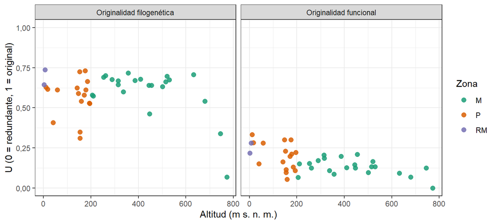

Figura 2: Originalidad funcional y filogenética por sitio (U = Q de la dimensión / Q taxonómica) frente a la altitud. Se excluyen los sitios con una sola especie.

```r
red_sitios %>%
  filter(!is.nan(U_FD)) %>%                                         # Sin los sitios de una especie
  pivot_longer(c(U_FD, U_PD),
               names_to = "Indice",
               values_to = "U") %>%
  mutate(Indice = recode(Indice,
                         U_FD = "Originalidad funcional",
                         U_PD = "Originalidad filogenética")) %>%
  ggplot(aes(Altitud, U, color = Zona)) +
  geom_point(size = 2.3, alpha = 0.85) +
  facet_wrap(~ Indice) +
  scale_color_manual(values = cols_zona) +
  scale_y_continuous(limits = c(0, 1), labels = coma) +
  labs(x = "Altitud (m s. n. m.)",
       y = "U (0 = redundante, 1 = original)") +
  theme_bw(base_size = 11)
```

## 1.3 Sitios que se salen del patrón

Si FD acompaña a TD, un sitio con más FD de la que “le tocaría” por su TD tiene especies funcionalmente más distintas que el promedio. Una regresión simple sirve para encontrarlos (es exploratoria: no reemplaza un modelo nulo de rasgos).

**Código**

```r
modelo <- lm(FD ~ TD, data = sitios_3d)            # FD esperada según la TD del sitio
sitios_3d$residuo_FD <- resid(modelo)              # Positivo: más FD de la esperada

bind_rows(
  sitios_3d %>% slice_max(residuo_FD, n = 3) %>%
    mutate(Tipo = "Más FD de la esperada"),
  sitios_3d %>% slice_min(residuo_FD, n = 3) %>%
    mutate(Tipo = "Menos FD de la esperada")
) %>%
  dplyr::select(Tipo, Sites, Zona, S, TD, FD, residuo_FD) %>%
  tabla("Sitios con los mayores residuos de la regresión FD ~ TD", digits = 2)
```

Sitios con los mayores residuos de la regresión FD ~ TD

| Tipo | Sites | Zona | S | TD | FD | residuo_FD |
| --- | --- | --- | --- | --- | --- | --- |
| Más FD de la esperada | 10P | P | 7 | 5,69 | 1,38 | 0,20 |
| Más FD de la esperada | 39P | P | 6 | 4,21 | 1,30 | 0,16 |
| Más FD de la esperada | 9P | P | 8 | 4,44 | 1,28 | 0,13 |
| Menos FD de la esperada | 42RM | RM | 27 | 16,20 | 1,36 | -0,09 |
| Menos FD de la esperada | 38M | M | 8 | 3,79 | 1,05 | -0,08 |
| Menos FD de la esperada | 1M | M | 2 | 1,55 | 1,00 | -0,07 |

**TipCómo leerlo**

Los sitios con más FD de la esperada son de la planicie (`P`), donde conviven herbívoros, omnívoros e invertívoros (el CWM del Taller 2 lo mostró). Los de menos FD de la esperada tienen especies de dietas muy parecidas para su número de especies efectivas. Para el estudio de caso, esta tabla es un buen punto de partida para elegir **qué sitios describir en detalle** en la discusión.

# 2. ¿Las brechas entre dimensiones son reales?

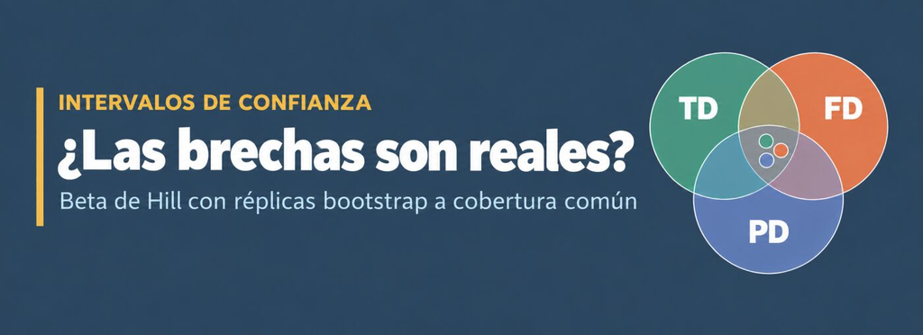

En el taller se usó `nboot = 0` para que todo corriera en segundos. Sin réplicas no hay intervalos de confianza, y una diferencia de 0,05 entre dos betas puede ser azar. Aquí se repite la beta de Hill con 20 réplicas *bootstrap* (en el informe conviene usar 50 o más).

**Código**

```r
set.seed(2026)                                        # El bootstrap usa números aleatorios: semilla fija
nivel <- int3d$cobertura_beta                          # La misma cobertura común del taller

pares <- combn(zonas_id, 2, simplify = FALSE) %>%      # Matrices de dos columnas por par de zonas
  set_names(map_chr(., paste, collapse = "_vs_")) %>%
  purrr::map(\(p) biol_zona[, p, drop = FALSE])
ali <- alinear_beta(pares, arbol_filo)                 # Para PD

# Conserva Beta, LCL y UCL (límites del intervalo de confianza del 95 %)
con_ic <- function(res, dim) map_dfr(res, ~ .x$beta) %>%
  transmute(Par = Dataset, Order.q, Dimension = dim, Beta, LCL, UCL)

beta_ic <- bind_rows(
  iNEXTbeta3D(pares,
              diversity = "TD",
              datatype = "abundance",
              base = "coverage",
              level = nivel, nboot = 20) %>%
              con_ic("TD"),
  iNEXTbeta3D(pares,
              diversity = "FD",
              datatype = "abundance",
              base = "coverage",
              level = nivel,
              nboot = 20,
              FDdistM = as.matrix(rasgos.d),
              FDtype = "AUC", FDcut_number = 15) %>%
              con_ic("FD"),
  iNEXTbeta3D(ali$pairs_aligned,
              diversity = "PD",
              datatype = "abundance",
              base = "coverage",
              level = nivel,
              nboot = 20,
              PDtree = ali$tree_aligned,
              PDtype = "meanPD") %>%
              con_ic("PD")
)
```

**Código**

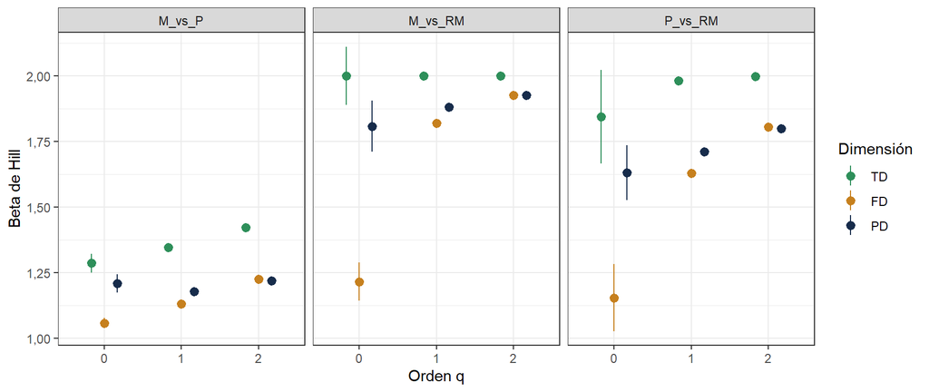

Figura 3: Beta de Hill a cobertura común con su intervalo de confianza del 95 % (20 réplicas bootstrap), por par de zonas, dimensión y orden q.

```r
beta_ic %>%
  mutate(Dimension = factor(Dimension, levels = c("TD", "FD", "PD"))) %>%
  ggplot(aes(factor(Order.q),
             Beta, color = Dimension)) +
  geom_pointrange(aes(ymin = LCL, ymax = UCL),                     # Punto = estimación; línea = intervalo
                  position = position_dodge(width = 0.5)) +
  facet_wrap(~ Par) +
  scale_color_manual(values = cols_dim) +
  scale_y_continuous(labels = coma) +
  labs(x = "Orden q",
       y = "Beta de Hill",
       color = "Dimensión") +
  theme_bw(base_size = 11)
```

**ImportanteLectura**

- En `M_vs_RM` con q = 0, el intervalo de la beta funcional (1,14 a 1,29) no se solapa con el de la taxonómica: el **reemplazo funcional** que se leyó en el taller es real.
- Cuando dos intervalos sí se solapan (revise en la figura FD y PD con q = 2), la conclusión correcta es “**no se distinguen**”, no “son iguales”.
- Las tablas y figuras del estudio de caso deben llevar estos intervalos. Es uno de los elementos del nivel avanzado de la ruta mínima.

# 3. ¿Cuánto depende la integración de la calidad de los rasgos?

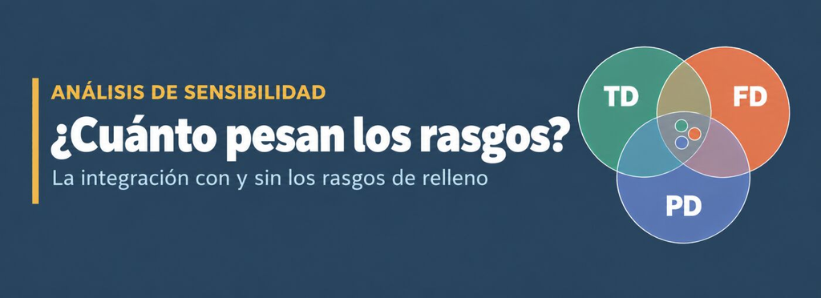

En el Taller 2 se advirtió que `BodyLength`, `BodyLengthMax` y `ShapeFactor` tienen **valores de relleno** repetidos en casi todas las especies. Si esos rasgos hacen que las especies parezcan más similares de lo que son, la redundancia funcional del taller estaría inflada. Se comprueba repitiendo el análisis **sin** ellos.

**Código**

```r
rasgos_sin <- rasgos1[, c("TrophicLevel", vars_bin)]          # Solo nivel trófico y los seis hábitos de dieta
dist_sin   <- FD::gowdis(rasgos_sin,
                         asym.bin = match(vars_bin, colnames(rasgos_sin)))   # Mismos binarios asimétricos

rao_con <- Rao(biol_zona,
               dfunc = rasgos.d,
               dphyl = NULL,
               Jost = FALSE)  # Con los 10 rasgos (taller)
rao_sin <- Rao(biol_zona,
               dfunc = dist_sin,
               dphyl = NULL,
               Jost = FALSE)  # Sin los rasgos de relleno

int_sin <- integrar_3d(biol_zona,
                       dist_sin,
                       arbol_filo)       # Hill con la nueva distancia

sens_red <- tibble(
  Zona = zonas_id,
  `R funcional (10 rasgos)` = 1 - as.numeric(rao_con$FD$Alpha / rao_con$TD$Alpha),
  `R funcional (7 rasgos)`  = 1 - as.numeric(rao_sin$FD$Alpha / rao_sin$TD$Alpha)
)
tabla(sens_red, "Redundancia funcional por zona con y sin los rasgos de relleno", digits = 2)
```

Redundancia funcional por zona con y sin los rasgos de relleno

| Zona | R funcional (10 rasgos) | R funcional (7 rasgos) |
| --- | --- | --- |
| M | 0,89 | 0,75 |
| P | 0,83 | 0,64 |
| RM | 0,77 | 0,47 |

**Código**

```r
sens_beta <- int3d$beta %>%
             filter(Dimension == "FD") %>%
  dplyr::select(Par, Order.q, `β FD (10 rasgos)` = Beta) %>%
  left_join(int_sin$beta %>%
              filter(Dimension == "FD") %>%
              dplyr::select(Par, Order.q, `β FD (7 rasgos)` = Beta),
            by = c("Par", "Order.q"))
tabla(sens_beta, "Beta funcional de Hill a cobertura común con y sin los rasgos de relleno", digits = 2)
```

Beta funcional de Hill a cobertura común con y sin los rasgos de relleno

| Par | Order.q | β FD (10 rasgos) | β FD (7 rasgos) |
| --- | --- | --- | --- |
| M_vs_P | 0 | 1,06 | 1,10 |
| M_vs_P | 1 | 1,13 | 1,14 |
| M_vs_P | 2 | 1,23 | 1,25 |
| M_vs_RM | 0 | 1,22 | 1,25 |
| M_vs_RM | 1 | 1,82 | 1,87 |
| M_vs_RM | 2 | 1,93 | 1,96 |
| P_vs_RM | 0 | 1,16 | 1,15 |
| P_vs_RM | 1 | 1,63 | 1,69 |
| P_vs_RM | 2 | 1,81 | 1,88 |

**ImportanteLección para el estudio de caso**

- La **magnitud** de la redundancia sí depende de los rasgos: sin los valores de relleno, la redundancia funcional de `RM` baja de 0,77 a 0,47. Lo mismo pasa con la FD alfa.
- El **patrón** de la beta funcional casi no cambia: `M_vs_RM` con q = 0 pasa de 1,22 a 1,25 y el orden de los pares se mantiene. El reemplazo funcional es robusto.
- En el documento del estudio de caso, un análisis de sensibilidad como este (con y sin los rasgos dudosos) convierte una limitación en un resultado defendible.

# 4. Reportar la beta en una escala de 0 a 1

La beta de Hill para dos unidades va de 1 a 2, una escala poco intuitiva fuera del curso. `iNEXTbeta3D()` también devuelve **disimilitudes** de 0 (idénticas) a 1 (nada en común) (Chao et al., 2023). En el taller, `integrar_3d()` ya guarda la de tipo Sørensen (`1-C`):

**Código**

```r
int3d$beta %>%
  dplyr::select(-Beta) %>%                                          # Solo la disimilitud 1-C
  pivot_wider(names_from = Dimension,
              values_from = Disimilitud) %>%
  arrange(Order.q, Par) %>%
  tabla("Disimilitud tipo Sørensen (1-C) entre pares de zonas, a cobertura común", digits = 2)
```

Disimilitud tipo Sørensen (1-C) entre pares de zonas, a cobertura común

| Par | Order.q | TD | FD | PD |
| --- | --- | --- | --- | --- |
| M_vs_P | 0 | 0,29 | 0,06 | 0,21 |
| M_vs_RM | 0 | 1,00 | 0,22 | 0,81 |
| P_vs_RM | 0 | 0,84 | 0,16 | 0,63 |
| M_vs_P | 1 | 0,43 | 0,18 | 0,24 |
| M_vs_RM | 1 | 1,00 | 0,86 | 0,91 |
| P_vs_RM | 1 | 0,99 | 0,70 | 0,78 |
| M_vs_P | 2 | 0,59 | 0,37 | 0,36 |
| M_vs_RM | 2 | 1,00 | 0,96 | 0,96 |
| P_vs_RM | 2 | 1,00 | 0,89 | 0,89 |

**TipCómo redactarlo**

“Montaña y desembocadura no comparten especies (1-C = 1 en TD), pero con q = 0 solo el 22 % de su diversidad funcional es exclusiva de una de las dos zonas.” La disimilitud se lee como una **proporción no compartida**, lo que facilita comunicar el resultado a un público no especializado. `iNEXTbeta3D()` devuelve además `1-U` (tipo Jaccard), `1-V` y `1-S`; en el informe basta con declarar cuál se usa.

# 5. La integración en el documento del estudio de caso

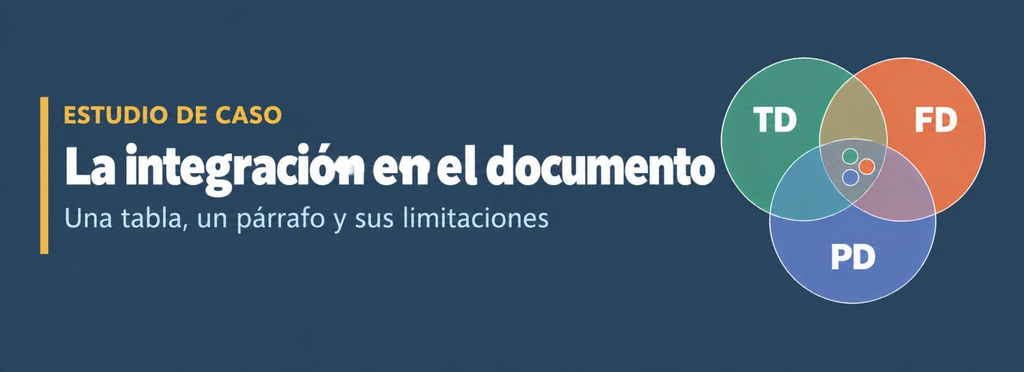

La ruta mínima pide **una tabla o figura que compare TD, FD y PD para la misma pregunta** y **un párrafo** que diga dónde coinciden y dónde divergen. Esta función arma la tabla a partir de la salida de `integrar_3d()`:

**Código**

```r
# tabla_integracion(): una fila por unidad (alfa) o por par (beta); columnas TD, FD y PD para q = 0, 1, 2
tabla_integracion <- function(int) {
  alfa <- int$alfa %>%
    mutate(Escala = "Alfa (números efectivos)",
           Comparacion = Unidad)
  beta <- int$beta %>%
    mutate(Escala = "Beta de Hill (1 a 2)",
           Comparacion = Par, Valor = Beta)
  bind_rows(alfa, beta) %>%
    mutate(Columna = paste0(Dimension,
                            " q=", Order.q)) %>%                     # p. ej. "FD q=1"
    dplyr::select(Escala, Comparacion,
                  Columna, Valor) %>%
    pivot_wider(names_from = Columna,
                values_from = Valor) %>%
    dplyr::select(Escala, Comparacion,
                  starts_with("TD"), starts_with("FD"),
                  starts_with("PD"))     # Agrupa por dimensión
}

ti <- tabla_integracion(int3d)
ti %>%
  dplyr::select(-Escala) %>%
  tabla(paste0("TD, FD y PD a cobertura común (alfa: ", dec(int3d$cobertura_alfa, 3),
               "; beta: ", dec(int3d$cobertura_beta, 3), ")"),
                digits = 2) %>%
  pack_rows(index = table(fct_inorder(ti$Escala))) %>%      # Bloque alfa y bloque beta
  add_header_above(c(" " = 1, "TD" = 3,
                     "FD" = 3, "PD" = 3))                   # Encabezado por dimensión
```

TD, FD y PD a cobertura común (alfa: 0,961; beta: 0,996)

| Comparacion | TD TD q=0 | TD TD q=1 | TD TD q=2 | FD FD q=0 | FD FD q=1 | FD FD q=2 | PD PD q=0 | PD PD q=1 | PD PD q=2 |
| --- | --- | --- | --- | --- | --- | --- | --- | --- | --- |
| **Alfa (números efectivos)** |  |  |  |  |  |  |  |  |  |
| M | 9,75 | 5,87 | 4,49 | 1,95 | 1,51 | 1,39 | 3,66 | 2,24 | 1,80 |
| P | 16,84 | 11,14 | 8,82 | 3,16 | 1,99 | 1,67 | 6,12 | 2,87 | 1,94 |
| RM | 53,00 | 24,47 | 15,39 | 4,30 | 2,91 | 2,58 | 17,22 | 5,18 | 2,63 |
| **Beta de Hill (1 a 2)** |  |  |  |  |  |  |  |  |  |
| M_vs_P | 1,29 | 1,35 | 1,42 | 1,06 | 1,13 | 1,23 | 1,21 | 1,18 | 1,22 |
| M_vs_RM | 2,00 | 2,00 | 2,00 | 1,22 | 1,82 | 1,93 | 1,81 | 1,88 | 1,93 |
| P_vs_RM | 1,84 | 1,98 | 2,00 | 1,16 | 1,63 | 1,81 | 1,63 | 1,71 | 1,80 |

**NotaQué debe acompañar a la tabla**

1. **Las coberturas comunes** (en el título, como aquí).
2. **Los intervalos de confianza** si se usó bootstrap (sección 2).
3. **El párrafo de integración** (plantilla del recuadro ✍️ 4 del taller).
4. **Las limitaciones**: calidad de los rasgos (sección 3), tipo de árbol y esfuerzo de muestreo.

# 6. Escenarios y redacciones para practicar

## 6.1 Cuatro escenarios: ¿qué herramienta responde la pregunta?

1. Una corporación ambiental quiere saber si **una ciénaga restaurada recuperó las funciones** de una ciénaga de referencia, aunque tenga otras especies.
2. Un grupo de estudiantes tiene 6 sitios de bosque seco con esfuerzo muy distinto y quiere comparar **cuántos linajes** hay en cada uno.
3. Se pide una sola cifra para decir **qué fracción de la diversidad funcional regional** se debe a diferencias entre tipos de hábitat.
4. Se quiere saber si en un arrecife **las especies raras aportan funciones nuevas** o repiten las de las dominantes.

**TipRespuestas sugeridas**

1. **B2 funcional** (`iNEXTbeta3D(diversity = "FD")`) entre las dos ciénagas, junto a la TD: una beta TD alta con beta FD baja indicaría reemplazo funcional (las funciones se recuperaron con otras especies).
2. **B1 filogenético** (`estimate3D(diversity = "PD", base = "coverage")`): corrige el esfuerzo. Con 6 sitios conviene revisar que ninguno tenga muy pocas especies.
3. **A2** con números equivalentes (`Rao(..., Jost = TRUE)`): la beta proporcional de FD.
4. **B1 funcional comparando q = 0 y q = 2** (o la razón FD/TD en cada q): si FD crece mucho al pasar de q = 2 a q = 0, las raras aportan funciones nuevas; si casi no crece, las repiten.

## 6.2 Redacciones: recomendada frente a evitar

| Redacción recomendada | Redacción que se debe evitar |
| --- | --- |
| «La desembocadura reúne más especies, linajes y grupos funcionales efectivos que la montaña, pero su ventaja es mucho menor en FD (2,2 veces) que en TD (5,4 veces).» | «La desembocadura es la zona más diversa.» |
| «Montaña y desembocadura no comparten especies, pero con q = 0 comparten buena parte de sus funciones: hay reemplazo funcional.» | «Las tres dimensiones muestran lo mismo.» |
| «La redundancia funcional es alta, aunque está inflada por rasgos con valores de relleno; sin ellos baja de 0,77 a 0,47 en la desembocadura.» | «La desembocadura es poco redundante y por eso es frágil.» |
| «La beta se comparó a una cobertura común de 0,996, con 20 réplicas bootstrap.» | Reportar betas sin indicar la cobertura ni el método. |

# Lecturas de referencia

Chao, A., Thorn, S., Chiu, C.-H., Moyes, F., Hu, K.-H., Chazdon, R. L., Wu, J., Magnago, L. F. S., Dornelas, M., Zelený, D., Colwell, R. K., y Magurran, A. E. (2023). Rarefaction and extrapolation with beta diversity under a framework of Hill numbers: The iNEXT.beta3D standardization. *Ecological Monographs*, *93*(4), e1588.

Devictor, V., Mouillot, D., Meynard, C., Jiguet, F., Thuiller, W., y Mouquet, N. (2010). Spatial mismatch and congruence between taxonomic, phylogenetic and functional diversity: the need for integrative conservation strategies in a changing world. *Ecology Letters*, *13*(8), 1030-1040.